# Aplicação da técnica quantitativa do Grupo 4 (vespertino) - Práticas de Pesquisa em Sociologia

Giovanna Claudino de Almeida Silva

2025-08-16

Nesse documento vamos unificar as duas técnicas aplicadas nos dados obtidos pelo grupo 4, do vespertino, da disciplina Práticas de Pesquisa em Sociologia. A nossa pergunta de pesquisa é “Como o G1 enquadrou a violência política sofrida e cometida por mulheres em cargos eletivos, levando em conta a ideologia de seus partidos?”. Nossa hipótese é que o enquadramento do G1 sobre violência política varia de acordo com o gênero e ideologia política das pessoas ocupantes de cargos no legislativo e executivo envolvidas nestes casos. Isto é, a maneira como a mídia noticia casos de violência política tende a variar a depender do partido político ao qual os envolvidos pertencem, bem como tende a variar dependendo se a violência foi praticada ou sofrida por homens ou mulheres.

Como técnicas quantitativas a serem aplicadas, escolhemos o uso de n-gramas para as notícias, e a frequência de partidos mais comuns nas categorias: mulheres agressoras, homens agressores, mulheres vítimas, e homens vítimas. Nesse arquivo não haverá uma análise das técnicas, só um registro de sua aplicação.

A técnica dos n-gramas consiste em identificar sequências de palavras que aparecem lado a lado, pois ela permite visualizar os padrões linguísticos mais recorrentes no conjunto de textos. Usamos bigramas, que são pares de palavras, para títulos e subtítulos, e trigramas, que são trios de palavras, para o corpo das matérias. Essa separação foi feita porque os títulos sintetizam o que é considerado mais relevante na notícia, enquanto o texto completo oferece elementos mais amplos do enquadramento. Essa técnica será utilizada para entender melhor os enquadramentos das notícias, mas também para fazer um levantamento dos atores mais frequentes nas notícias, e auxiliar a escolha dos casos para a análise qualitativa.

A frequência dos partidos servirá como uma descrição inicial dos dados, permitindo visualizar quais partidos estão mais associados aos episódios de violência. Esses dados quantitativos vão auxiliar na seleção de casos para a análise qualitativa, oferecendo um critério baseado na relevância dos partidos para a escolha dos casos.

**Vamos iniciar com a aplicação da técnica dos n-gramas.** Inicialmente, vamos criar um objeto com as stopwords, e uma função para criar os n-gramas e gerar os gráficos. Eu decidi usar um objeto para as stopwords, e definir ele á parte no começo do código, para facilitar a edição dele. Ou seja, foram criado os gráficos dos n-gramas algumas vezes antes da versão final, e a cada etapa eu editava esse objeto.

```r
# Lista de stopwords (truncada aqui, mas mantenha completa no seu script real)
stopwords <- c(
  "a", "as", "o", "os", "um", "uma", "uns", "umas",
  "de", "da", "do", "das", "dos", "em", "na", "no", "nas", "nos", "por", "para",
  "com", "sem", "sobre", "sob", "entre", "contra", "após", "ante", "até", "desde",
  "durante", "mediante", "perante", "segundo", "conforme", "consoante",
  "e", "ou", "mas", "porém", "contudo", "todavia", "entretanto", "no entanto",
  "portanto", "logo", "pois", "porque", "como", "quando", "onde", "enquanto",
  "embora", "ainda que", "mesmo que", "caso", "se", "que", "qual", "quais",
  "eu", "tu", "ele", "ela", "nós", "vós", "eles", "elas", "me", "te", "se", "nos",
  "vos","meu", "minha", "meus", "minhas", "teu", "tua", "teus", "tuas", "seu", "sua",
  "seus", "suas", "nosso", "nossa", "nossos", "nossas", "vosso", "vossa", "vossos",
  "vossas","este", "esta", "estes", "estas", "esse", "essa", "esses", "essas", "aquele",
  "aquela","aqueles", "aquelas", "isto", "isso", "aquilo", "quem", "cujo", "cuja",
  "cujos", "cujas", "não", "sim", "já", "ainda", "mais", "menos", "muito", "pouco", "bem",
  "mal", "aqui", "ali", "lá", "cá", "aí", "aonde", "assim", "então", "agora", "hoje", "ontem",
  "amanhã", "sempre", "nunca", "jamais", "talvez", "acaso", "apenas", "só", "somente",
  "também", "inclusive", "ser", "estar", "ter", "haver", "ir", "vir", "fazer", "dar",
  "dizer", "ver", "saber", "poder", "querer", "dever", "ficar", "passar", "chegar",
  "sair", "entrar", "voltar", "trazer", "levar", "pôr", "tirar", "deixar", "encontrar",
  "é", "são", "foi", "foram", "era", "eram", "será", "serão", "seja", "sejam",
  "está", "estão", "esteve", "estiveram", "estava", "estavam", "estará", "estarão",
  "tem", "têm", "teve", "tiveram", "tinha", "tinham", "terá", "terão", "há", "houve",
  "houveram", "havia", "haviam", "haverá", "haverão", "segunda", "terça", "quarta", "quinta",
  "sexta","sábado","domingo", "nesta", "neste", "nessa", "nesse", "dessa", "desse", "até hoje"
)

# Função auxiliar para gerar bigramas ou trigramas, gráfico e salvar
gerar_ngramas <- function(df, nome_base, tipo = "bigrama", cor = "gray40", arquivo_saida) {
  df_filtrado <- df %>%
    mutate(Relevância_num = as.numeric(as.character(Relevância))) %>%
    filter(!is.na(Relevância_num) & Relevância_num != 0)

  # Verificação: número de registros filtrados por relevância
  cat("[", nome_base, "] Total após filtrar por relevância: ", nrow(df_filtrado), "\n")

  if (tipo == "bigrama") {
    df_texto <- df_filtrado %>%
      filter(!(is.na(titulo) & is.na(subtitulo))) %>%
      mutate(
        titulo = ifelse(is.na(titulo), "", titulo),
        subtitulo = ifelse(is.na(subtitulo), "", subtitulo),
        texto_combinado = paste(titulo, subtitulo, sep = " ")
      ) %>%
      select(texto_combinado) %>%
      filter(texto_combinado != "" & texto_combinado != " ")

    # Verificação: exemplos de textos combinados
    cat("Exemplo de texto combinado:\n")
    print(head(df_texto$texto_combinado, 3))

    ngram_coluna <- "bigram"
    ngram_n <- 2
    texto_base <- df_texto
    texto_campo <- "texto_combinado"
  } else if (tipo == "trigrama") {
    df_texto <- df_filtrado %>%
      filter(!is.na(conteudo) & conteudo != "" & str_trim(conteudo) != "") %>%
      select(conteudo)

    # Verificação: exemplos de conteúdos válidos
    cat("Exemplo de conteúdo:\n")
    print(head(df_texto$conteudo, 3))

    ngram_coluna <- "trigram"
    ngram_n <- 3
    texto_base <- df_texto
    texto_campo <- "conteudo"
  } else {
    stop("Tipo inválido. Use 'bigrama' ou 'trigrama'.")
  }

  ngramas <- texto_base %>%
    unnest_tokens(ng, .data[[texto_campo]], token = "ngrams", n = ngram_n) %>%
    separate(ng, paste0("palavra", 1:ngram_n), sep = " ") %>%
    filter(if_all(starts_with("palavra"), ~ !.x %in% stopwords & str_detect(.x, "[[:alpha:]]"))) %>%
    unite(!!ngram_coluna, starts_with("palavra"), sep = " ") %>%
    count(!!sym(ngram_coluna), sort = TRUE) %>%
    top_n(20, n)

  # Verificação: imprimir os top ngramas
  cat("\nTop 5 ", tipo, ":\n")
  print(head(ngramas, 5))

  grafico <- ngramas %>%
    mutate(!!ngram_coluna := reorder(!!sym(ngram_coluna), n)) %>%
    ggplot(aes_string(x = ngram_coluna, y = "n")) +
    geom_col(fill = cor, alpha = 0.8) +
    coord_flip() +
    labs(
      title = paste("Top 20", tipo, "mais frequentes em", nome_base),
      subtitle = ifelse(tipo == "bigrama", "Título + Subtítulo", "Conteúdo das Notícias"),
      x = stringr::str_to_title(tipo),
      y = "Frequência"
    ) +
    theme_minimal()

  ggsave(arquivo_saida, grafico, width = 12, height = 8, dpi = 300, bg = "white")
  cat("Gráfico salvo em:", arquivo_saida, "\n\n")

  return(list(dados = ngramas, grafico = grafico))
}
```

Agora, vamos importar as bases, executar a função nelas e visualizar os gráficos.

```r
# Importar bases de dados (ajuste os caminhos conforme necessário)
mulheres_dados <- read_excel("C:/Users/gigic/Downloads/m_vitimas.xlsx")
homens_dados <- read_excel("C:/Users/gigic/Downloads/h_vitimas.xlsx")
# Executar análises
bigramas_mulheres <- gerar_ngramas(mulheres_dados, "mulheres vítimas", tipo = "bigrama", cor = "darkred", arquivo_saida = "bigramas_mulheres.png")
```

```
## [ mulheres vítimas ] Total após filtrar por relevância:  151
## Exemplo de texto combinado:
## [1] "Vídeo mostra confusão com deputada Alê Silva em aeroporto de BH: 'A senhora está infringindo a lei', diz policial Segundo o agente que a acompanhava, filmar área de segurança do aeroporto infringe legislação federal. Ela disse que tomou a atitude para evitar que alguém 'plantasse' algo em su…
## [2] "Polícia Civil de Porto Alegre investiga denúncia de ameaças contra ex-deputada Manuela D'Ávila e filha Candidata à Vice-Presidência da República em 2018 disse que sofreu ameaças após fotos da filha, de cinco anos, serem divulgadas na internet."
## [3] "Vereadora de Contagem, na Grande BH, procura polícia após ser vítima de ataques racistas Enquanto a parlamentar discursava, um homem a atacou, chamando-a de \"nariz amassado”. Foi dela o único voto contrário ao projeto de lei que classificou academias e igrejas como serviços essenciais na ci…
##
## Top 5  bigrama :
## # A tibble: 5 × 2
##   bigram                 n
##   <chr>              <int>
## 1 redes sociais         22
## 2 violência política    17
## 3 isa penna             14
## 4 benny briolly         10
## 5 deputada andréia      10
```

```
## Gráfico salvo em: bigramas_mulheres.png
```

```r
trigramas_mulheres <- gerar_ngramas(mulheres_dados, "mulheres vítimas", tipo = "trigrama", cor = "indianred", arquivo_saida = "trigramas_mulheres.png")
```

```
## [ mulheres vítimas ] Total após filtrar por relevância:  151
## Exemplo de conteúdo:
## [1] "A deputada federal Alessandra Silva (PSL-MG), conhecida como Alê Silva , filmou parte da área de inspeção do Aeroporto Internacional de Belo Horizonte , em Confins, na Região Metropolitana, na manhã desta terça-feira (25), depois de ser retirada do avião por um policial federal ao se negar a…
## [2] "A Polícia Civil do Rio Grande do Sul confirmou, nesta quinta-feira (3), que a ex-deputada federal Manuela D'Ávila (PCdoB) registrou boletim de ocorrência relatando ameaças contra si e sua filha, de cinco anos . Segundo a chefe de polícia do RS, delegada Nadine Anflor, o caso é investigado pe…
## [3] "A vereadora de Contagem, na Região Metropolitana de Belo Horizonte, Moara Sabóia (PT), procurou a polícia depois de ser alvo de ataques racistas durante uma sessão virtual da câmara nesta semana. Ela recebeu as ofensas durante uma sessão que discutia a reabertura de academias e templos relig…
##
## Top 5  trigrama :
## # A tibble: 5 × 2
##   trigram                       n
##   <chr>                     <int>
## 1 deputada isa penna           34
## 2 isa penna psol               19
## 3 minas gerais almg            17
## 4 deputada mônica seixas       15
## 5 deputado wellington moura    14
```

```
## Gráfico salvo em: trigramas_mulheres.png
```

```r
bigramas_homens   <- gerar_ngramas(homens_dados, "homens vítimas", tipo = "bigrama", cor = "navy", arquivo_saida = "bigramas_homens.png")
```

```
## [ homens vítimas ] Total após filtrar por relevância:  46
## Exemplo de texto combinado:
## [1] "Polícia Civil abre investigação sobre vídeo com ameaça a Lula Governador João Doria diz ter determinado imediata abertura de investigação. Ele recebeu uma carta denunciando o caso e procurou a presidente nacional do PT, deputada federal Gleisi Hoffmann. Vídeo com ameaças foi feito por um hom…
## [2] "Comitiva de Haddad é atacada com ovos em Cordeirópolis; VÍDEO Câmera de segurança flagrou momento que pessoa não identificada atirou dois ovos na direção do candidato ao governo de São Paulo."
## [3] "PT aciona Conselho de Ética contra deputado que ameaçou Lula em vídeo com arma dentro da Alesp Em vídeo publicado nas redes sociais, Coronel Telhada (PP) comenta fala em que ex-presidente orienta militância sindical a pressionar parlamentares para que votem a favor de propostas que interessa…
##
## Top 5  bigrama :
## # A tibble: 5 × 2
##   bigram               n
##   <chr>            <int>
## 1 câmara municipal     5
## 2 vídeo mostra         5
## 3 ex vereador          4
## 4 maciel santos        4
## 5 polícia civil        4
```

```
## Gráfico salvo em: bigramas_homens.png
```

```r
trigramas_homens  <- gerar_ngramas(homens_dados, "homens vítimas", tipo = "trigrama", cor = "cornflowerblue", arquivo_saida = "trigramas_homens.png")
```

```
## [ homens vítimas ] Total após filtrar por relevância:  46
## Exemplo de conteúdo:
## [1] "O governador de São Paulo, João Doria (PSDB), determinou que a polícia investigue um homem responsável por divulgar um vídeo fazendo ameaças de morte ao ex-presidente Lula. Ele também telefonou para a presidente nacional do PT, a deputada federal Gleisi Hoffmann, para falar sobre o caso, apó…
## [2] "A comitiva do candidato a governador de São Paulo Fernando Haddad (PT) foi atacada com ovos durante caminhada pelas ruas de Cordeirópolis (SP) . O incidente ocorreu na manhã desta quinta-feira (6), quando o candidato cumpria agenda no município. Depois de assinar uma carta de compromisso com…
## [3] "A bancada de deputados do Partido dos Trabalhadores ( PT ) na Assembleia Legislativa de São Paulo ( Alesp ) protocolou nesta quarta-feira (6) uma representação por quebra de decoro no Conselho de Ética da Casa contra o deputado estadual Coronel Telhada (PP), gravado nas dependências da Alesp…
##
## Top 5  trigrama :
## # A tibble: 5 × 2
##   trigram                     n
##   <chr>                   <int>
## 1 roberto maciel santos       9
## 2 atirou diversas vezes       7
## 3 vereador renato freitas     7
## 4 vereador sidnei toaldo      6
## 5 aline dequi palma           5
```

```
## Gráfico salvo em: trigramas_homens.png
```

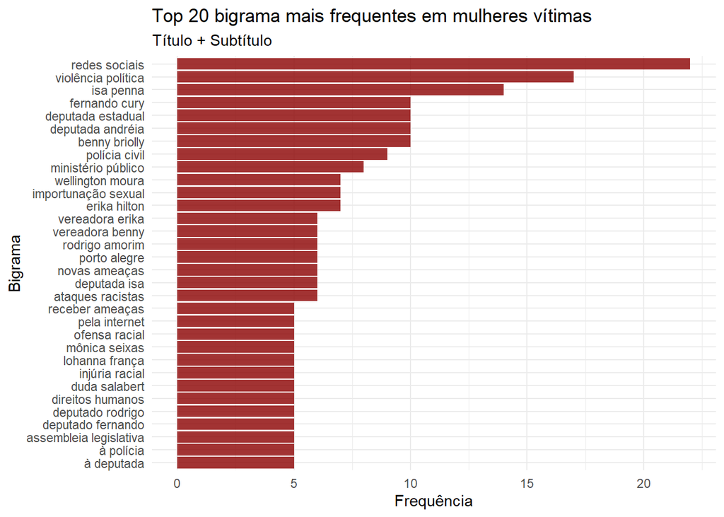

```r
# Exibir gráficos (opcional)
print(bigramas_mulheres$grafico)
```

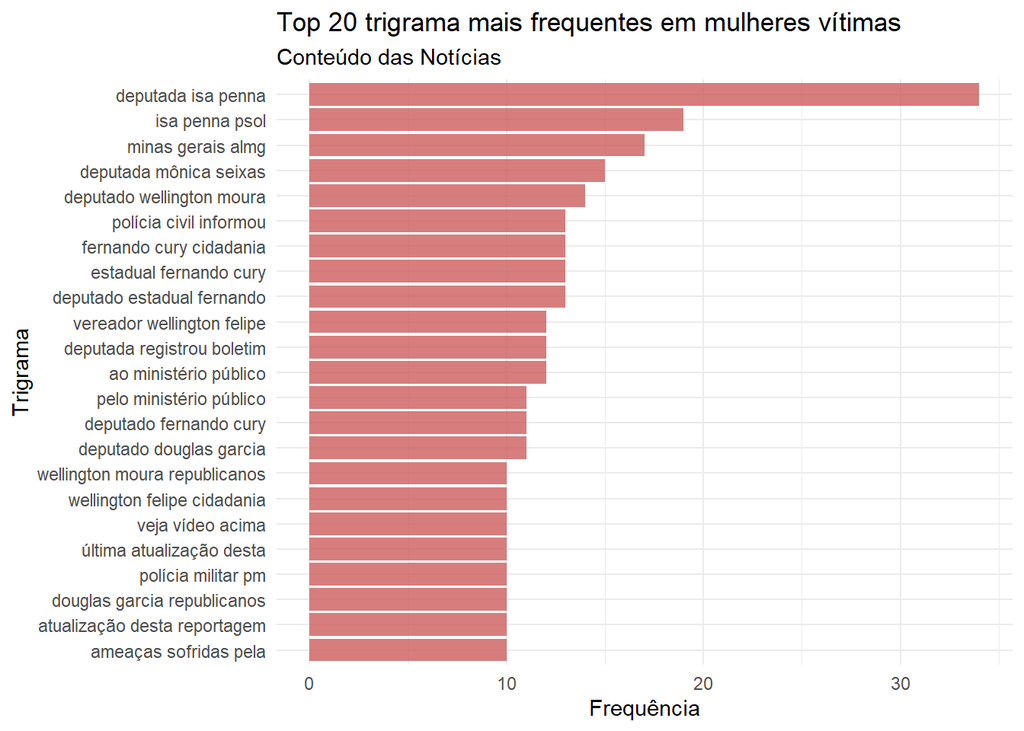

```r
print(trigramas_mulheres$grafico)
```

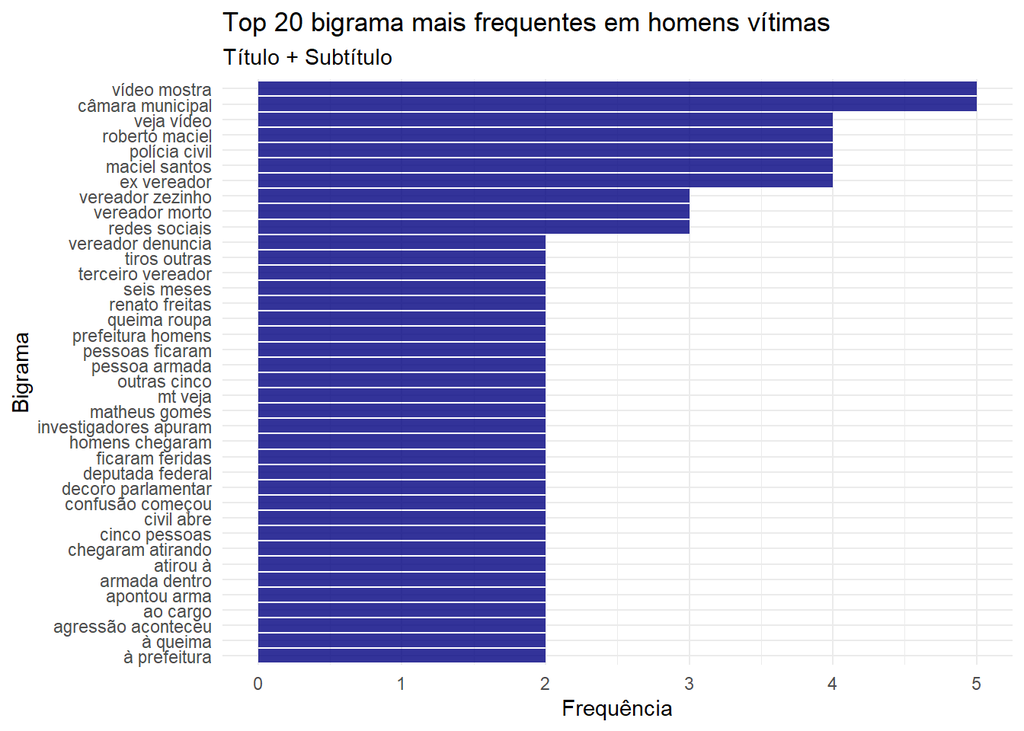

```r
print(bigramas_homens$grafico)
```

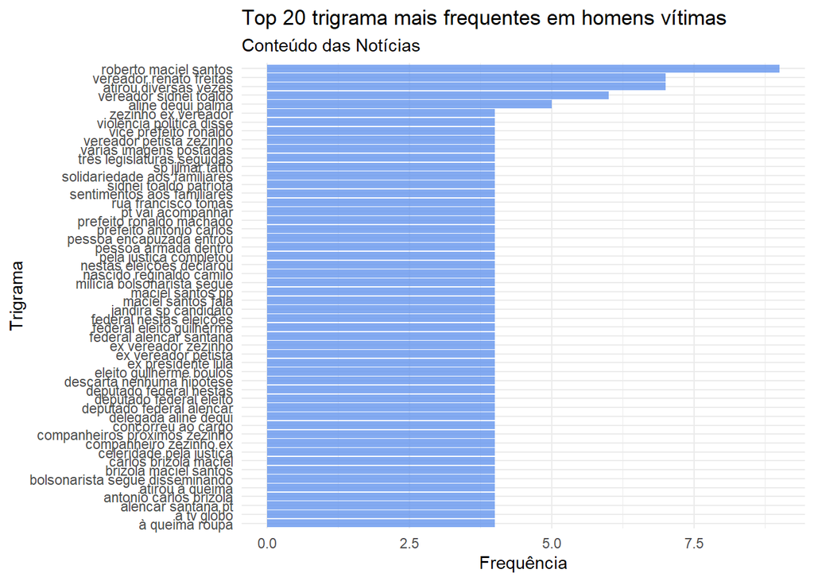

```r
print(trigramas_homens$grafico)
```

**Agora, vamos aplicar a frequência de partidos por categorias (mulheres agressoras, mulheres vítimas, homens agressores, homens vítimas).** Inicialmente, vamos juntar as duas bases que usamos na primeira técncia e conferir se a junção ocorreu corretamente.

```r
# Juntar os dados
dados_geral <- rbind(homens_dados, mulheres_dados)

# Verificação:
# Verificar número de linhas e colunas após união
print(dim(dados_geral))
```

```
## [1] 198  21
```

```r
# Visualizar primeiros registros
head(dados_geral)
```

| titulo | subtitulo | autor | conteudo | regiao | data | link | busca | partidos_mencionados | Relevância | Cargo Agressor(a) | Cargo Agredido(a) | Partido Agressor | Partido Agredido | Nome Agressor(a) | Nome Agredido(a) | Tipo de Violência | Gênero Agressor | Gênero Agredido | Observação | ...21 |
| --- | --- | --- | --- | --- | --- | --- | --- | --- | --- | --- | --- | --- | --- | --- | --- | --- | --- | --- | --- | --- |
| Polícia Civil abre investigação sobre vídeo com ameaça a Lula | Governador João Doria diz ter determinado imediata abertura de investigação. Ele recebeu uma carta denunciando o caso e procurou a presidente nacional do PT, deputada federal Gleisi Hoffmann. Vídeo co… | Por G1 SP | O governador de São Paulo, João Doria (PSDB), determinou que a polícia investigue um homem responsável por divulgar um vídeo fazendo ameaças de morte ao ex-presidente Lula. Ele também telefonou para a… | SP - Sao Paulo | 15/03/2021 21h03 | https://g1.globo.com/sp/sao-paulo/noticia/2021/03/15/doria-aciona-presidente-do-pt-para-falar-sobre-ameaca-de-morte-a-lula-e-pede-investigacao.ghtml | violência governador, violências governadores, agressões governadores, ameaça governador, ameaça deputado, ameaças governadores, ameaças deputados | PSDB, PT | 1 | - | Pré candidato | - | PT | - | Lula | Ameaça | H | H C | NÃO se encaixa, mas a notícia é interessante | NA |
| Comitiva de Haddad é atacada com ovos em Cordeirópolis; VÍDEO | Câmera de segurança flagrou momento que pessoa não identificada atirou dois ovos na direção do candidato ao governo de São Paulo. | Por g1 Piracicaba e Região | A comitiva do candidato a governador de São Paulo Fernando Haddad (PT) foi atacada com ovos durante caminhada pelas ruas de Cordeirópolis (SP) . O incidente ocorreu na manhã desta quinta-feira (6), qu… | SP - Piracicaba Regiao | 08/09/2022 15h44 | https://g1.globo.com/sp/piracicaba-regiao/eleicoes/2022/noticia/2022/09/08/comitiva-de-haddad-e-atacada-com-ovos-em-cordeiropolis-video.ghtml | violência governador, violência vereador, ameaça governador, ameaça vereador, ameaças governadores, ameaças vereadores, ataque governador, ataque vereador, ataques vereadores | PT | 1 | Pessoa não identificada | Candidato a governador | - | PT | - | Fernando Haddad | Arremeço de ovos | - | H C | NA | NA |
| PT aciona Conselho de Ética contra deputado que ameaçou Lula em vídeo com arma dentro da Alesp | Em vídeo publicado nas redes sociais, Coronel Telhada (PP) comenta fala em que ex-presidente orienta militância sindical a pressionar parlamentares para que votem a favor de propostas que interessam a… | Por Rodrigo Rodrigues, g1 SP | A bancada de deputados do Partido dos Trabalhadores ( PT ) na Assembleia Legislativa de São Paulo ( Alesp ) protocolou nesta quarta-feira (6) uma representação por quebra de decoro no Conselho de Étic… | SP - Sao Paulo | 06/04/2022 18h08 | https://g1.globo.com/sp/sao-paulo/noticia/2022/04/06/pt-aciona-conselho-de-etica-contra-deputado-que-ameacou-lula-por-video-com-arma-dentro-da-alesp.ghtml | violência deputado, violências deputados, ameaça deputado, ameaça senador, ameaças deputados, ameaças senadores | PP, PT | 1 | Deputado Estadual | Ex-presidente | PP | PT | Coronel Telhada | Lula | Ameaça | H C | H C | NA | NA |
| VÍDEO: presidente da Aleam leva soco no rosto de prefeito de Borba durante comício | Ainda não há informação sobre as causas que motivaram a agressão. Deputado estadual informou que registrou Boletim de Ocorrência. | Por g1 AM | O prefeito de Borba (a 149 quilômetros de Manaus ), Simão Peixoto (Progressitas), agrediu com um soco no rosto o deputado estadual Roberto Cidade (União Brasil), presidente da Assembleia Legislativa d… | AM - Amazonas | 02/09/2022 21h59 | https://g1.globo.com/am/amazonas/eleicoes/2022/noticia/2022/09/02/video-presidente-da-aleam-leva-soco-no-rosto-de-prefeito-de-borba-durante-comicio.ghtml | violência deputado, violência vereador, violência prefeito, violências deputados, violências vereadores, violências prefeitos, agressão deputado, agressão vereador, agressão prefeito, agressões deputa… | UNIÃO | 1 | Prefeito | Deputado Estadual | Progressitas | União | Simão Peixoto | Roberto Cidade | Violência física | H | H | NA | NA |
| Corpo do ex-vereador Zezinho do PT é velado na Grande SP | Político foi assassinado nesta sexta-feira (28). Moradores que testemunharam ataque afirmam que um veículo com uma pessoa armada dentro se aproximou do vereador e atirou à queima-roupa. Zezinho foi ca… | Por g1 SP | O corpo do ex-vereador Zezinho do PT , de 51 anos, foi velado no Ginásio de Esportes de Jandira , na Grande São Paulo , na manhã deste sábado (29). O sepultamento ocorreu às 16h, no Cemitério municipa… | SP - Sao Paulo | 29/10/2022 10h29 | https://g1.globo.com/sp/sao-paulo/noticia/2022/10/29/corpo-do-ex-vereador-zezinho-do-pt-e-velado-na-grande-sp.ghtml | violência deputado, violência vereador, violência prefeito, violências deputados, violências vereadores, violências prefeitos, ataque deputado, ataque vereador, ataque prefeito, ataques deputados, ata… | PSDB, PSOL, PT | 1 | - | Ex-vereador | - | PT | - | Zezinho | Assassinato | H | H | Zezinho era um vereador atuante em Jandira, autor de diversas denúncias de corrupção na cidade em áreas como a da Saúde e de compras municipais. | NA |
| Polícia ouve testemunha do assassinato de ex-vereador do PT e trabalha com hipótese de crime político | Zezinho foi morto a tiros nesta sexta-feira (28). Investigadores apuram se crime foi cometido por adversários bolsonaristas ou vingança por conta das denúncias que ele fez de irregularidades no setor … | Por g1 SP e TV Globo | A Polícia Civil ouviu, na manhã deste sábado (29), uma testemunha do assassinato do ex-vereador Zezinho do PT . A investigação é feita pela seccional de Carapicuíba, que também convocou para prestar d… | SP - Sao Paulo | 29/10/2022 12h33 | https://g1.globo.com/sp/sao-paulo/noticia/2022/10/29/policia-ouve-testemunha-do-assassinato-de-ex-vereador-do-pt-e-trabalha-com-hipotese-de-crime-politico.ghtml | violência deputado, violência vereador, violência prefeito, violências deputados, violências vereadores, violências prefeitos, ataque deputado, ataque vereador, ataque prefeito, ataques vereadores, at… | PSDB, PSOL, PT | 1 | CASO JÁ MENCIONADO - EX-VEREADOR ZEZINHO | Ex-vereador | - | PT | - | Zezinho | Assassinato | - | H | NA | NA |

Agora, vamos aplicar uma função que padronize e limpe nossa base de dados. Por exemplo, se em uma linha foi digitado “Homem” e outra “H”, ou foi digitado “Psol” e outra “PSOL”, será criado novas colunas padronizando isso. Também vamos padronizar os NAs e outras variáveis como “não consta na notícia”, ou “-”, ou “não se aplica”, em uma variável chamada “Não se aplica ou não encontrado”. Vamos aplicar essa função a base de dados, e verificar como ela ficou depois dessa alteração.

```r
#Função de limpeza e padronização

limpar_dados <- function(df) {
  df %>%
    mutate(
      # Padronizar gênero do agressor
      genero_agressor_pad = case_when(
        is.na(`Gênero Agressor`) | `Gênero Agressor` == "-" ~ "Não se aplica ou não encontrado",
        str_detect(`Gênero Agressor`, "(?i)H") & str_detect(`Gênero Agressor`, "(?i)M") ~ "Ambos",
        str_detect(`Gênero Agressor`, "(?i)H") ~ "Homem",
        str_detect(`Gênero Agressor`, "(?i)M") ~ "Mulher",
        TRUE ~ "Não se aplica ou não encontrado"
      ),

      # Padronizar gênero do agredido
      genero_agredido_pad = case_when(
        is.na(`Gênero Agredido`) | `Gênero Agredido` == "-" ~ "Não se aplica ou não encontrado",
        str_detect(`Gênero Agredido`, "(?i)H") & str_detect(`Gênero Agredido`, "(?i)M") ~ "Ambos",
        str_detect(`Gênero Agredido`, "(?i)H") ~ "Homem",
        str_detect(`Gênero Agredido`, "(?i)M") ~ "Mulher",
        TRUE ~ "Não se aplica ou não encontrado"
      ),

      # Padronizar partidos do agressor
      partido_agressor_pad = tolower(`Partido Agressor`),
      partido_agressor_pad = case_when(
        is.na(partido_agressor_pad) | partido_agressor_pad %in% c("-", "não consta na notícia") ~ "não se aplica ou não encontrado",
        partido_agressor_pad %in% c("progressitas") ~ "progressistas",
        partido_agressor_pad %in% c("cidadania sp", "cidadania") ~ "cidadania",
        partido_agressor_pad %in% c("republicanos", "republicanos ") ~ "republicanos",
        partido_agressor_pad %in% c("psol/republicanos") ~ "psol e republicanos",
        partido_agressor_pad %in% c("psol/") ~ "psol",
        TRUE ~ partido_agressor_pad
      ),

      # Padronizar partidos do agredido
      partido_agredido_pad = tolower(`Partido Agredido`),
      partido_agredido_pad = case_when(
        is.na(partido_agredido_pad) | partido_agredido_pad %in% c("-", "não consta na notícia") ~ "não se aplica ou não encontrado",
        partido_agredido_pad %in% c("progressitas") ~ "progressistas",
        partido_agredido_pad %in% c("cidadania sp", "cidadania") ~ "cidadania",
        partido_agredido_pad %in% c("republicanos", "republicanos ") ~ "republicanos",
        partido_agredido_pad %in% c("psol e pcdo b", "psol e pcdob") ~ "psol e pcdob",
        partido_agredido_pad %in% c("pt, pcdo b e psol") ~ "pt e pcdob e psol",
        partido_agredido_pad %in% c("psol/") ~ "psol",
        TRUE ~ partido_agredido_pad
      ),

      # Uniformizar separadores
      partido_agressor_pad = str_replace_all(partido_agressor_pad, ",", " e "),
      partido_agredido_pad = str_replace_all(partido_agredido_pad, ",", " e ")
    )
}

dados_geral <- limpar_dados(dados_geral)

# Verificação:
# Verificar se as colunas padronizadas foram criadas corretamente
table(dados_geral$genero_agressor_pad)
```

```
##
##                           Ambos                           Homem
##                               5                             106
##                          Mulher Não se aplica ou não encontrado
##                              17                              70
```

```r
table(dados_geral$partido_agressor_pad)
```

```
##
##                       cidadania                             mdb
##                               9                               8
## não se aplica ou não encontrado                            novo
##                             123                               2
##                        patriota                             pdt
##                               1                               1
##                              pl                         podemos
##                               3                               2
##                              pp                   progressistas
##                               2                               3
##                            prtb                             psb
##                               1                               2
##                             psc                             psd
##                               5                               6
##                            psdb                             psl
##                               3                               4
##                            psol             psol e republicanos
##                               6                               2
##                              pt                             ptb
##                               1                               5
##                    republicanos                     sem partido
##                               7                               1
##                           união
##                               1
```

Agora precisamos ajustar linhas que tem mais de um partido em uma categoria, por exemplo, se houve um agressor do PSOL e um do Cidadania, e aí na cédula está escrito “Psol/Cidadania”. Temos que duplicar essas linha, mas sem correr o risco de ter combinação cruzada, caso os partidos também estejam duplicados nas duas colunas de partidos (a referente a partidos dos agressores, e a referente a partido dos agredidos). Vamos fazer uma função para isso, e vamos verificar se a expansão das linhas ocorreu corretamente.

```r
#Função para expandir os partidos
expandir_partidos <- function(df, coluna_partido, prefixo) {
  df %>%
    separate_rows(!!sym(coluna_partido), sep = " e |/|,") %>%
    mutate(!!sym(coluna_partido) := str_trim(!!sym(coluna_partido))) %>%
    group_by(across(-!!sym(coluna_partido))) %>%
    mutate(linha_id = paste0(prefixo, "_", row_number())) %>%
    ungroup()
}

# Criar dados separados para análise:
dados_para_agressores <- expandir_partidos(dados_geral, "partido_agressor_pad", "agr")
dados_para_agredidos  <- expandir_partidos(dados_geral, "partido_agredido_pad",  "agd")

# Verificação:
# Conferir se a expansão duplicou apenas a coluna correta
head(dados_para_agressores)
```

| titulo | subtitulo | autor | conteudo | regiao | data | link | busca | partidos_mencionados | Relevância | Cargo Agressor(a) | Cargo Agredido(a) | Partido Agressor | Partido Agredido | Nome Agressor(a) | Nome Agredido(a) | Tipo de Violência | Gênero Agressor | Gênero Agredido | Observação | ...21 | genero_agressor_pad | genero_agredido_pad | partido_agressor_pad | partido_agredido_pad | linha_id |
| --- | --- | --- | --- | --- | --- | --- | --- | --- | --- | --- | --- | --- | --- | --- | --- | --- | --- | --- | --- | --- | --- | --- | --- | --- | --- |
| Polícia Civil abre investigação sobre vídeo com ameaça a Lula | Governador João Doria diz ter determinado imediata abertura de investigação. Ele recebeu uma carta denunciando o caso e procurou a presidente nacional do PT, deputada federal Gleisi Hoffmann. Vídeo co… | Por G1 SP | O governador de São Paulo, João Doria (PSDB), determinou que a polícia investigue um homem responsável por divulgar um vídeo fazendo ameaças de morte ao ex-presidente Lula. Ele também telefonou para a… | SP - Sao Paulo | 15/03/2021 21h03 | https://g1.globo.com/sp/sao-paulo/noticia/2021/03/15/doria-aciona-presidente-do-pt-para-falar-sobre-ameaca-de-morte-a-lula-e-pede-investigacao.ghtml | violência governador, violências governadores, agressões governadores, ameaça governador, ameaça deputado, ameaças governadores, ameaças deputados | PSDB, PT | 1 | - | Pré candidato | - | PT | - | Lula | Ameaça | H | H C | NÃO se encaixa, mas a notícia é interessante | NA | Homem | Homem | não se aplica ou não encontrado | pt | agr_1 |
| Comitiva de Haddad é atacada com ovos em Cordeirópolis; VÍDEO | Câmera de segurança flagrou momento que pessoa não identificada atirou dois ovos na direção do candidato ao governo de São Paulo. | Por g1 Piracicaba e Região | A comitiva do candidato a governador de São Paulo Fernando Haddad (PT) foi atacada com ovos durante caminhada pelas ruas de Cordeirópolis (SP) . O incidente ocorreu na manhã desta quinta-feira (6), qu… | SP - Piracicaba Regiao | 08/09/2022 15h44 | https://g1.globo.com/sp/piracicaba-regiao/eleicoes/2022/noticia/2022/09/08/comitiva-de-haddad-e-atacada-com-ovos-em-cordeiropolis-video.ghtml | violência governador, violência vereador, ameaça governador, ameaça vereador, ameaças governadores, ameaças vereadores, ataque governador, ataque vereador, ataques vereadores | PT | 1 | Pessoa não identificada | Candidato a governador | - | PT | - | Fernando Haddad | Arremeço de ovos | - | H C | NA | NA | Não se aplica ou não encontrado | Homem | não se aplica ou não encontrado | pt | agr_1 |
| PT aciona Conselho de Ética contra deputado que ameaçou Lula em vídeo com arma dentro da Alesp | Em vídeo publicado nas redes sociais, Coronel Telhada (PP) comenta fala em que ex-presidente orienta militância sindical a pressionar parlamentares para que votem a favor de propostas que interessam a… | Por Rodrigo Rodrigues, g1 SP | A bancada de deputados do Partido dos Trabalhadores ( PT ) na Assembleia Legislativa de São Paulo ( Alesp ) protocolou nesta quarta-feira (6) uma representação por quebra de decoro no Conselho de Étic… | SP - Sao Paulo | 06/04/2022 18h08 | https://g1.globo.com/sp/sao-paulo/noticia/2022/04/06/pt-aciona-conselho-de-etica-contra-deputado-que-ameacou-lula-por-video-com-arma-dentro-da-alesp.ghtml | violência deputado, violências deputados, ameaça deputado, ameaça senador, ameaças deputados, ameaças senadores | PP, PT | 1 | Deputado Estadual | Ex-presidente | PP | PT | Coronel Telhada | Lula | Ameaça | H C | H C | NA | NA | Homem | Homem | pp | pt | agr_1 |
| VÍDEO: presidente da Aleam leva soco no rosto de prefeito de Borba durante comício | Ainda não há informação sobre as causas que motivaram a agressão. Deputado estadual informou que registrou Boletim de Ocorrência. | Por g1 AM | O prefeito de Borba (a 149 quilômetros de Manaus ), Simão Peixoto (Progressitas), agrediu com um soco no rosto o deputado estadual Roberto Cidade (União Brasil), presidente da Assembleia Legislativa d… | AM - Amazonas | 02/09/2022 21h59 | https://g1.globo.com/am/amazonas/eleicoes/2022/noticia/2022/09/02/video-presidente-da-aleam-leva-soco-no-rosto-de-prefeito-de-borba-durante-comicio.ghtml | violência deputado, violência vereador, violência prefeito, violências deputados, violências vereadores, violências prefeitos, agressão deputado, agressão vereador, agressão prefeito, agressões deputa… | UNIÃO | 1 | Prefeito | Deputado Estadual | Progressitas | União | Simão Peixoto | Roberto Cidade | Violência física | H | H | NA | NA | Homem | Homem | progressistas | união | agr_1 |
| Corpo do ex-vereador Zezinho do PT é velado na Grande SP | Político foi assassinado nesta sexta-feira (28). Moradores que testemunharam ataque afirmam que um veículo com uma pessoa armada dentro se aproximou do vereador e atirou à queima-roupa. Zezinho foi ca… | Por g1 SP | O corpo do ex-vereador Zezinho do PT , de 51 anos, foi velado no Ginásio de Esportes de Jandira , na Grande São Paulo , na manhã deste sábado (29). O sepultamento ocorreu às 16h, no Cemitério municipa… | SP - Sao Paulo | 29/10/2022 10h29 | https://g1.globo.com/sp/sao-paulo/noticia/2022/10/29/corpo-do-ex-vereador-zezinho-do-pt-e-velado-na-grande-sp.ghtml | violência deputado, violência vereador, violência prefeito, violências deputados, violências vereadores, violências prefeitos, ataque deputado, ataque vereador, ataque prefeito, ataques deputados, ata… | PSDB, PSOL, PT | 1 | - | Ex-vereador | - | PT | - | Zezinho | Assassinato | H | H | Zezinho era um vereador atuante em Jandira, autor de diversas denúncias de corrupção na cidade em áreas como a da Saúde e de compras municipais. | NA | Homem | Homem | não se aplica ou não encontrado | pt | agr_1 |
| Polícia ouve testemunha do assassinato de ex-vereador do PT e trabalha com hipótese de crime político | Zezinho foi morto a tiros nesta sexta-feira (28). Investigadores apuram se crime foi cometido por adversários bolsonaristas ou vingança por conta das denúncias que ele fez de irregularidades no setor … | Por g1 SP e TV Globo | A Polícia Civil ouviu, na manhã deste sábado (29), uma testemunha do assassinato do ex-vereador Zezinho do PT . A investigação é feita pela seccional de Carapicuíba, que também convocou para prestar d… | SP - Sao Paulo | 29/10/2022 12h33 | https://g1.globo.com/sp/sao-paulo/noticia/2022/10/29/policia-ouve-testemunha-do-assassinato-de-ex-vereador-do-pt-e-trabalha-com-hipotese-de-crime-politico.ghtml | violência deputado, violência vereador, violência prefeito, violências deputados, violências vereadores, violências prefeitos, ataque deputado, ataque vereador, ataque prefeito, ataques vereadores, at… | PSDB, PSOL, PT | 1 | CASO JÁ MENCIONADO - EX-VEREADOR ZEZINHO | Ex-vereador | - | PT | - | Zezinho | Assassinato | - | H | NA | NA | Não se aplica ou não encontrado | Homem | não se aplica ou não encontrado | pt | agr_1 |

```r
table(dados_para_agressores$partido_agressor_pad)
```

```
##
##                       cidadania                             mdb
##                               9                               8
## não se aplica ou não encontrado                            novo
##                             123                               2
##                        patriota                             pdt
##                               1                               1
##                              pl                         podemos
##                               3                               2
##                              pp                   progressistas
##                               2                               3
##                            prtb                             psb
##                               1                               2
##                             psc                             psd
##                               5                               6
##                            psdb                             psl
##                               3                               4
##                            psol                              pt
##                               8                               1
##                             ptb                    republicanos
##                               5                               9
##                     sem partido                           união
##                               1                               1
```

```r
table(dados_para_agressores$genero_agressor_pad)
```

```
##
##                           Ambos                           Homem
##                               7                             106
##                          Mulher Não se aplica ou não encontrado
##                              17                              70
```

Vamos fazer uma função para gerar os gráficos e tabelas, criar as bases e aplciar a função a elas.

```r
# Função auxiliar para gerar tabela e gráfico
gerar_tabela_grafico <- function(df, coluna_partido, cor, titulo, arquivo) {
  tabela <- as.data.frame(table(df[[coluna_partido]]))
  colnames(tabela) <- c("Partido", "Frequencia")
  tabela$Porcentagem <- prop.table(tabela$Frequencia) * 100

  grafico <- ggplot(tabela, aes(x = reorder(Partido, Frequencia), y = Frequencia)) +
    geom_bar(stat = "identity", fill = cor) +
    geom_text(aes(label = paste0(round(Porcentagem, 1), "%")), hjust = -0.1, size = 3) +
    coord_flip() +
    labs(x = "Partido", y = "Frequência", title = titulo) +
    theme_minimal() +
    ylim(0, max(tabela$Frequencia) * 1.15)

  ggsave(arquivo, plot = grafico, width = 12, height = 8, dpi = 300, bg = "white")

  return(list(tabela = tabela, grafico = grafico))
}

# Filtrar e gerar outputs para os quatro casos:

# Mulheres agressoras
dados_agressoras_mulheres <- dados_para_agressores %>% filter(genero_agressor_pad %in% c("Mulher", "Ambos"))
saida_am <- gerar_tabela_grafico(dados_agressoras_mulheres, "partido_agressor_pad", "firebrick", "Partidos de mulheres (ou ambos) que cometeram violência", "grafico_agressoras_mulheres.png")

# Mulheres vítimas
dados_vitimas_mulheres <- dados_para_agredidos %>% filter(genero_agredido_pad %in% c("Mulher", "Ambos"))
saida_vm <- gerar_tabela_grafico(dados_vitimas_mulheres, "partido_agredido_pad", "salmon", "Partidos de mulheres (ou ambos) que sofreram violência", "grafico_vitimas_mulheres.png")

# Homens agressores
dados_agressores_homens <- dados_para_agressores %>% filter(genero_agressor_pad %in% c("Homem", "Ambos"))
saida_ah <- gerar_tabela_grafico(dados_agressores_homens, "partido_agressor_pad", "dodgerblue", "Partidos de homens (ou ambos) que cometeram violência", "grafico_agressores_homens.png")

# Homens vítimas
dados_vitimas_homens <- dados_para_agredidos %>% filter(genero_agredido_pad %in% c("Homem", "Ambos"))
saida_vh <- gerar_tabela_grafico(dados_vitimas_homens, "partido_agredido_pad", "steelblue", "Partidos de homens (ou ambos) que sofreram violência", "grafico_vitimas_homens.png")

# VERIFICAÇÃO DOS DADOS FINAIS:
# Ver os dados tabulados antes do gráfico
print(saida_am$tabela)
```

```
##                            Partido Frequencia Porcentagem
## 1                              mdb          1    4.166667
## 2  não se aplica ou não encontrado          7   29.166667
## 3                             novo          2    8.333333
## 4                               pl          2    8.333333
## 5                    progressistas          2    8.333333
## 6                              psd          2    8.333333
## 7                              psl          2    8.333333
## 8                             psol          3   12.500000
## 9                     republicanos          2    8.333333
## 10                           união          1    4.166667
```

```r
print(saida_vm$tabela)
```

```
##                            Partido Frequencia Porcentagem
## 1                              cdn          1   0.6289308
## 2                        cidadania          2   1.2578616
## 3                              dem          3   1.8867925
## 4                              mdb          2   1.2578616
## 5  não se aplica ou não encontrado         25  15.7232704
## 6                             novo          2   1.2578616
## 7                    partido verde          1   0.6289308
## 8                         patriota          3   1.8867925
## 9             patriota (atual prd)          1   0.6289308
## 10                           pcdob          7   4.4025157
## 11                             pdt          4   2.5157233
## 12                              pl          1   0.6289308
## 13                         podemos          1   0.6289308
## 14                             psd          3   1.8867925
## 15                            psol         50  31.4465409
## 16                              pt         38  23.8993711
## 17                             ptb          3   1.8867925
## 18                              pv          4   2.5157233
## 19                            rede          1   0.6289308
## 20                    republicanos          6   3.7735849
## 21                           união          1   0.6289308
```

```r
print(saida_ah$tabela)
```

```
##                            Partido Frequencia Porcentagem
## 1                        cidadania          9   7.9646018
## 2                              mdb          7   6.1946903
## 3  não se aplica ou não encontrado         50  44.2477876
## 4                         patriota          1   0.8849558
## 5                              pdt          1   0.8849558
## 6                               pl          1   0.8849558
## 7                          podemos          2   1.7699115
## 8                               pp          2   1.7699115
## 9                    progressistas          1   0.8849558
## 10                            prtb          1   0.8849558
## 11                             psb          2   1.7699115
## 12                             psc          5   4.4247788
## 13                             psd          4   3.5398230
## 14                            psdb          3   2.6548673
## 15                             psl          2   1.7699115
## 16                            psol          7   6.1946903
## 17                             ptb          5   4.4247788
## 18                    republicanos          9   7.9646018
## 19                     sem partido          1   0.8849558
```

```r
print(saida_vh$tabela)
```

```
##                            Partido Frequencia Porcentagem
## 1  não se aplica ou não encontrado         12          24
## 2                            pcdob          1           2
## 3                               pl          1           2
## 4                          podemos          1           2
## 5                               pp          7          14
## 6                              psd          1           2
## 7                             psdb          3           6
## 8                              psl          1           2
## 9                             psol          2           4
## 10                              pt         11          22
## 11                             ptb          1           2
## 12                    republicanos          4           8
## 13                   solidariedade          3           6
## 14                           união          2           4
```

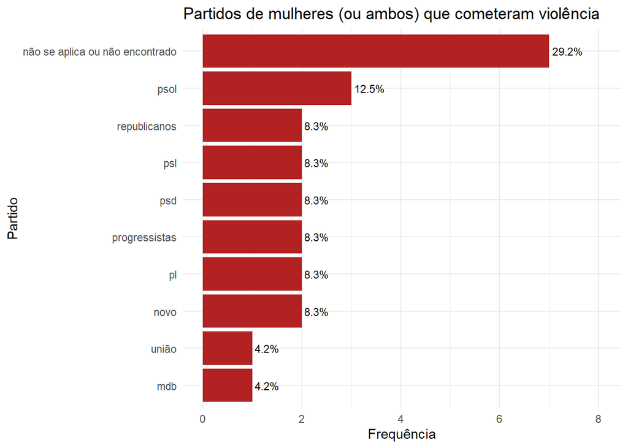

```r
# Visualizar gráficos manualmente (se quiser no console interativo)
print(saida_am$grafico)
```

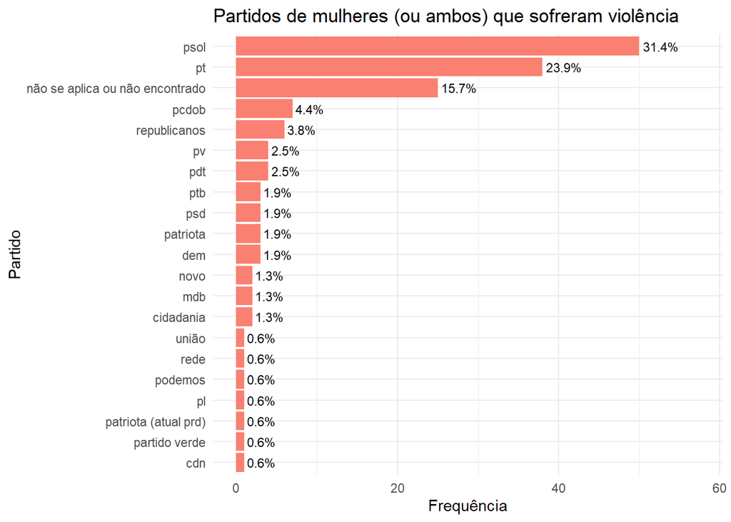

```r
print(saida_vm$grafico)
```

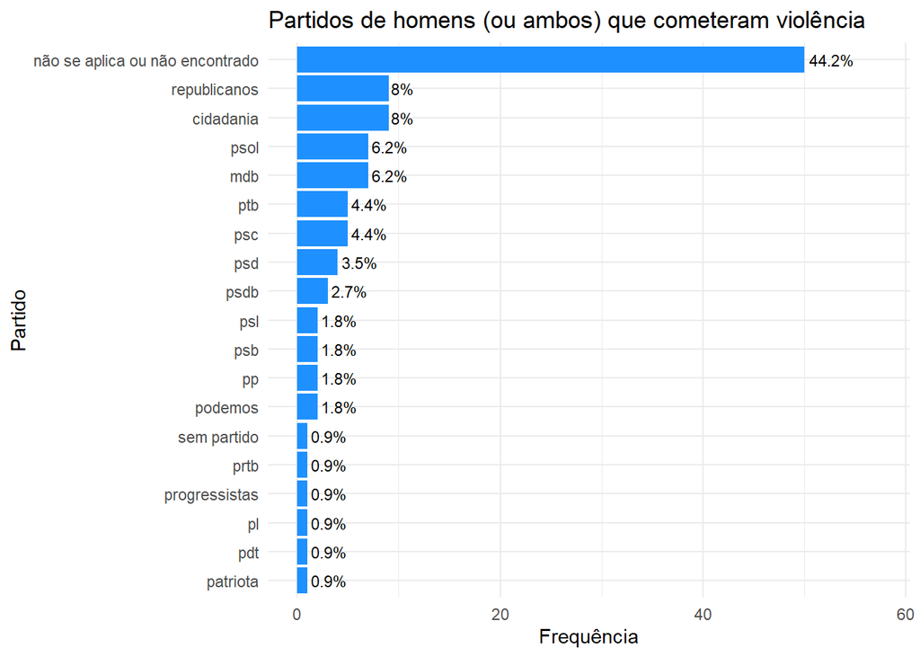

```r
print(saida_ah$grafico)
```

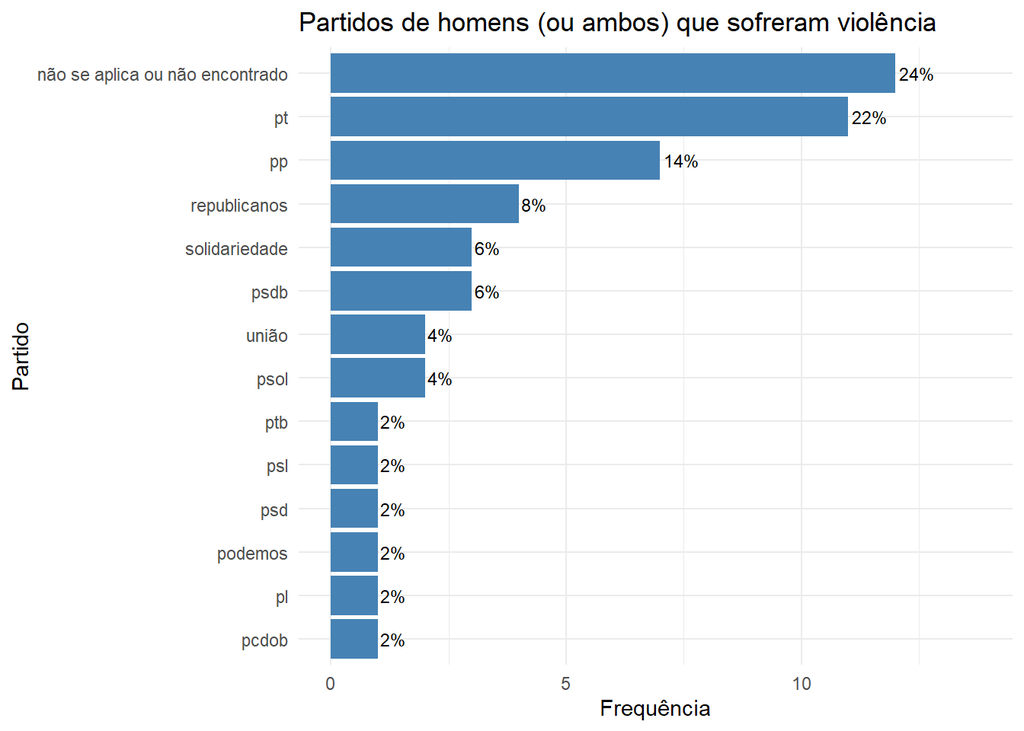

```r
print(saida_vh$grafico)
```

Por último, vamos verificar o percentual da categoria “Ambos” em cada base de dados. Esse foi um pedido dos outros integrantes do grupo. Alguns casos de violência possuem duas pessoas, uma de cada gênero, na categoria de agressores. Como dividimos a análise por gênero e posição da pessoa na violência, se tornou relevante entender o quão mesclados os gêneros estão em algumas dessas categorias.

```r
#Verificação da categoria "Ambos" em cada uma das tabelas

#Função para verificar
calcular_freq_e_pct_ambos <- function(df, coluna_genero) {
  total <- nrow(df)
  freq_ambos <- df %>% filter(!!sym(coluna_genero) == "Ambos") %>% nrow()
  pct_ambos <- (freq_ambos / total) * 100
  tibble(
    Frequencia = freq_ambos,
    Total = total,
    Percentual = pct_ambos
  )
}

# Aplicando para as 4 bases:
freq_pct_agressoras_mulheres <- calcular_freq_e_pct_ambos(dados_agressoras_mulheres, "genero_agressor_pad")
freq_pct_vitimas_mulheres <- calcular_freq_e_pct_ambos(dados_vitimas_mulheres, "genero_agredido_pad")
freq_pct_agressores_homens <- calcular_freq_e_pct_ambos(dados_agressores_homens, "genero_agressor_pad")
freq_pct_vitimas_homens <- calcular_freq_e_pct_ambos(dados_vitimas_homens, "genero_agredido_pad")

# Mostrar resultados
freq_pct_agressoras_mulheres
```

| Frequencia | Total | Percentual |
| --- | --- | --- |
| 7 | 24 | 29.16667 |

```r
freq_pct_vitimas_mulheres
```

| Frequencia | Total | Percentual |
| --- | --- | --- |
| 8 | 159 | 5.031447 |

```r
freq_pct_agressores_homens
```

| Frequencia | Total | Percentual |
| --- | --- | --- |
| 7 | 113 | 6.19469 |

```r
freq_pct_vitimas_homens
```

| Frequencia | Total | Percentual |
| --- | --- | --- |
| 8 | 50 | 16 |